# Modeling & Forecasting Atmospheric Carbon Concetration

Citlally Reynoso

1/19/2021

## Overview

Carbon dioxide is a greenhouse gas, it causes heat to remain trapped within the atmosphere of Earth. It is a naturally occurring gas, but human activities, such as the combustion of fossil fuels, disrupt the natural carbon cycle. Due to its greenhouse effect and the magnitude with which humans produce it, carbon dioxide is a crucial component in understanding climate change.

## About the Data

The data set has the carbon dioxide monthly means measured at Mauna Loa, Hawaii from 1958 to April 2020. Throughout this project I model and analyze the trend and seasonality of the CO2 monthly means throughout the years. I use this information to fit a Seasonal Autoregressive Integrated Moving Average (SARIMA) model to the data. I then forecasted CO2 levels using the SARIMA model to validate it and test its accuracy. Below is a short description of the columns in the data:

| column name | description |
| --- | --- |
| date | Year when carbon dioxide (CO2) reading was taken |
| season corr | Month when the reading was taken |
| decimal | Specific date -in decimal format- when reading was taken |
| average | Average CO2 parts per million (ppm) for the month (-99.99 means there is no data for that month) |
| interpolated | Average CO2 ppm for the month. Data was interpolated,predicted using a model, for months where reading was not available |
| trend | Trends observed in the data |
| days | Number of days for which we have data for that month. Until mid-1974 this column has -1 observations because the data for these months came from another lab. |

## Vizualizing the Data

```
##   date season corr  decimal average interpolated  trend days
## 1 1958           3 1958.208  315.71       315.71 314.62   -1
## 2 1958           4 1958.292  317.45       317.45 315.29   -1
## 3 1958           5 1958.375  317.50       317.50 314.71   -1
## 4 1958           6 1958.458  -99.99       317.10 314.85   -1
## 5 1958           7 1958.542  315.86       315.86 314.98   -1
## 6 1958           8 1958.625  314.93       314.93 315.94   -1
```

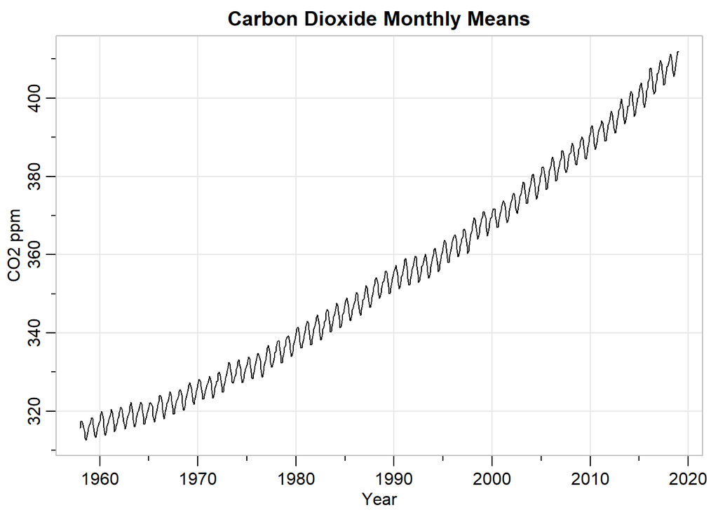

## Modeling

#### Autocorrelation and Partial Autocorrelation

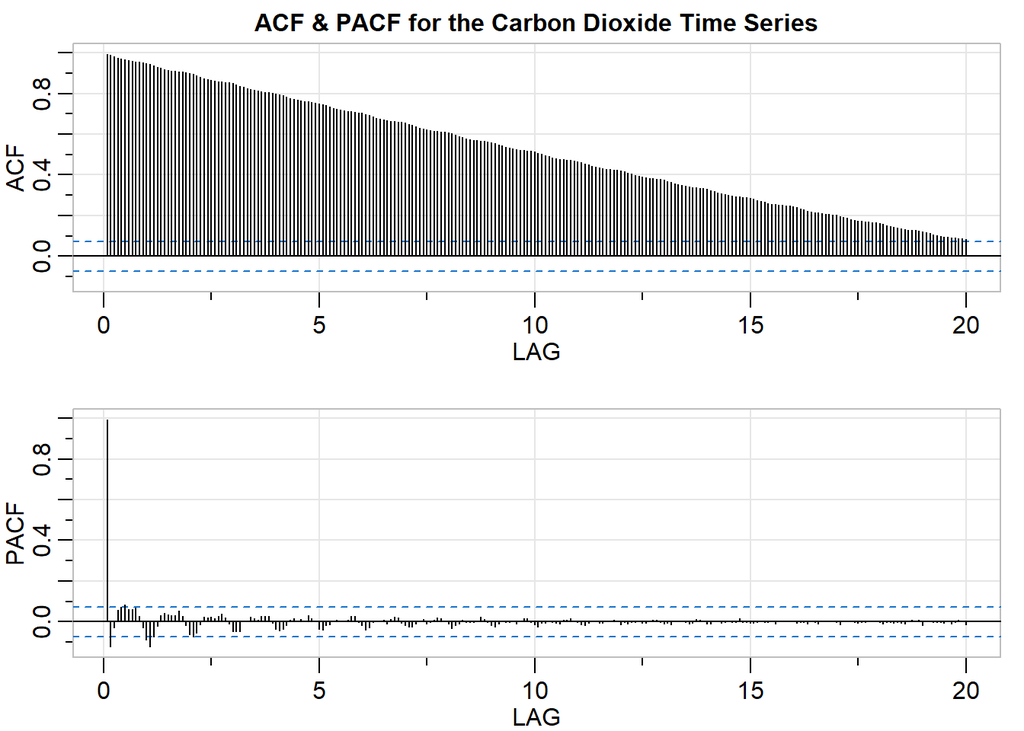

- The Autocorrelation Function (ACF) of the time series is significant until a lag of 20 years. The autocorrelation decayes slowly, which means that the time series is not stationary.
- The Partial Autocorrelation Function (PACF), on the other hand, seems to fall within the insignificant range before 2.5 lags. In order to explore this further, we can decompose the data into trend and seasonality.

#### Decomposing the data into Trend and Seasonality

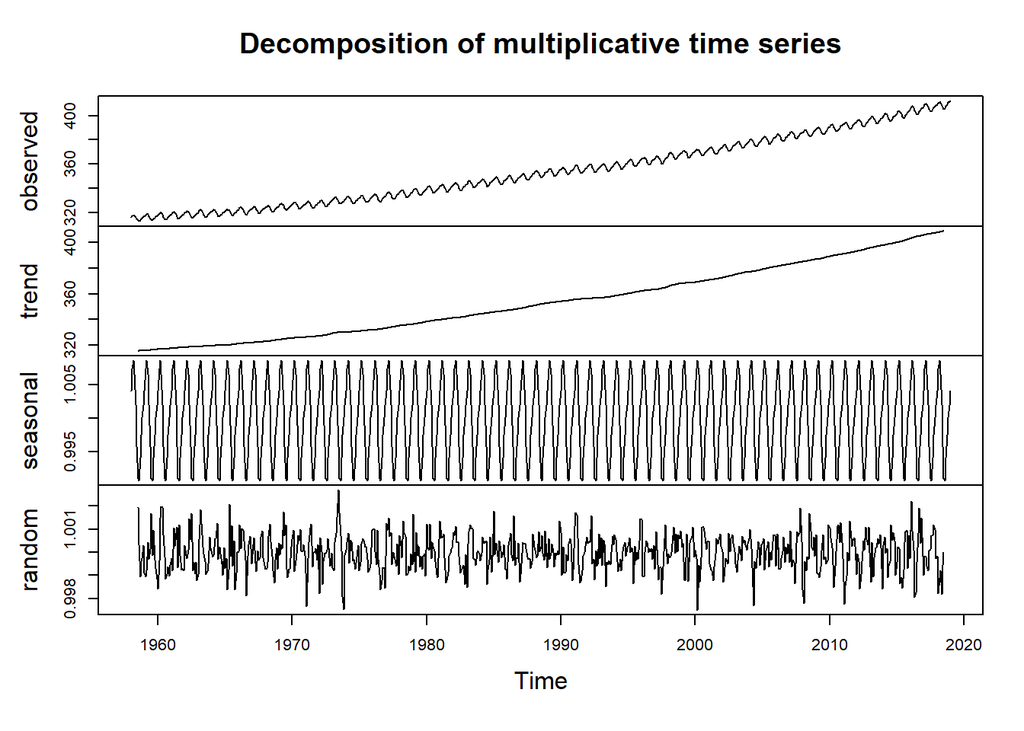

When we deconstruct the time series into trend and seasonality, we are able to visualize the influence that each one has on the data.

1. **Observed:** This is a visualization of the CO2 monthly means as they exist.
2. **Trend:** shows us there is a positive trend over time in the **carbon dioxide parts per million (CO2 ppm)** present in our atmosphere. As the years have gone by, there is a constant increase in the CO2 ppm.
3. **Seasonal:** graph shows an oscillating pattern in the CO2 monthly means. This indicates that the CO2 ppm are following a seasonal pattern throughout the year. During certain months, CO2 is generally higher and during others it tends to be lower.
4. **Random:** This is the variation in CO2 monthly means that is left over when trend and seasonality are accounted for. As you can see in the graph, when trend and seasonality are accounted for there is no discernible pattern left over in the data. This is what we call *white noise*.

#### Fitting trend into the model

```
##
## Call:
## lm(formula = interpolated ~ decimal, data = co2_mm)
##
## Residuals:
##    Min     1Q Median     3Q    Max
## -8.141 -3.071 -0.629  2.847 12.250
##
## Coefficients:
##               Estimate Std. Error t value Pr(>|t|)
## (Intercept) -2.775e+03  1.762e+01  -157.5   <2e-16 ***
## decimal      1.574e+00  8.856e-03   177.7   <2e-16 ***
## ---
## Signif. codes:  0 '***' 0.001 '**' 0.01 '*' 0.05 '.' 0.1 ' ' 1
##
## Residual standard error: 4.341 on 744 degrees of freedom
## Multiple R-squared:  0.977,  Adjusted R-squared:  0.9769
## F-statistic: 3.157e+04 on 1 and 744 DF,  p-value: < 2.2e-16
```

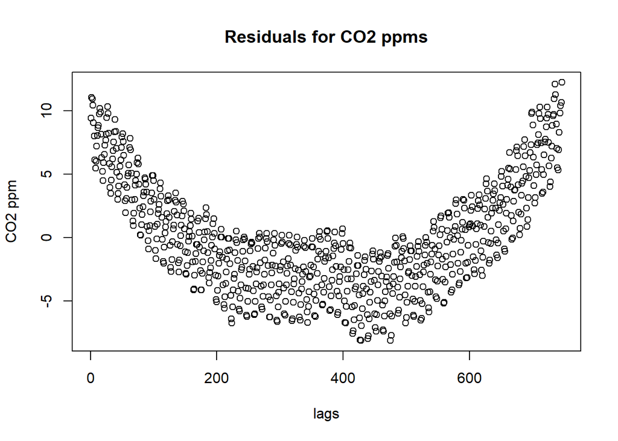

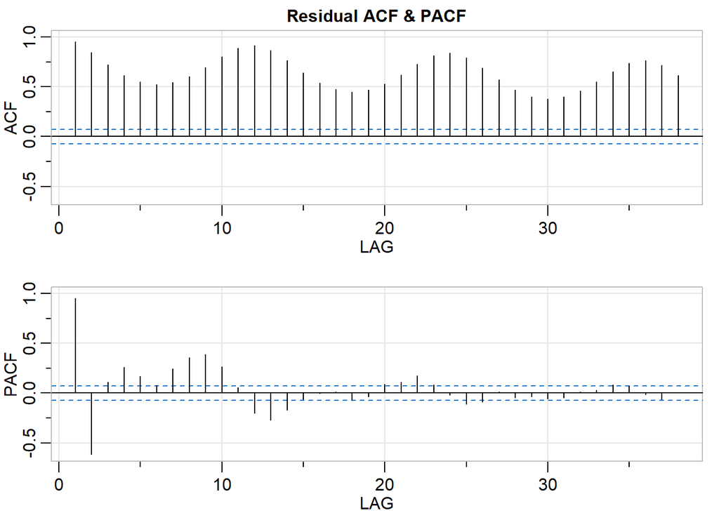

- The variable *decimal*, gives the exact date in decimal form for when the CO2 reading was taken. Including this variable in the model helps us account for the positive trend in the CO2 ppm.
- This predictor alone, gives us an **R-squared of 0.977.**
- Residuals allow us to see what kind of variance we still have not captured:
- **Residual Plot:** When looking at the residual plot, it is apparent that there is still a lot of variance unaccounted for. Specifically, there seems to be a quadratic term which is heavily influencing the data that we have not yet accounted for in this model.
- **ACF & PACF:** The ACF is still significant after a lot of lags, but now is moves up and down over the zero line. The PACF seems to have significance for more lags than before adding in the time factor.

#### Differentiating the Data Once:

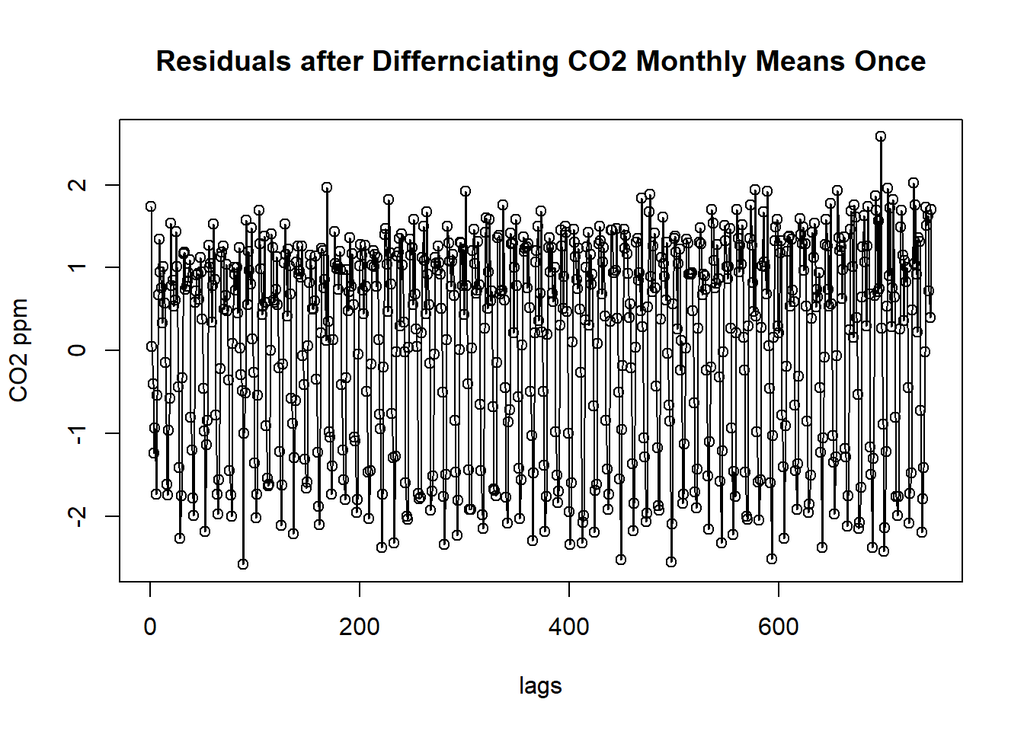

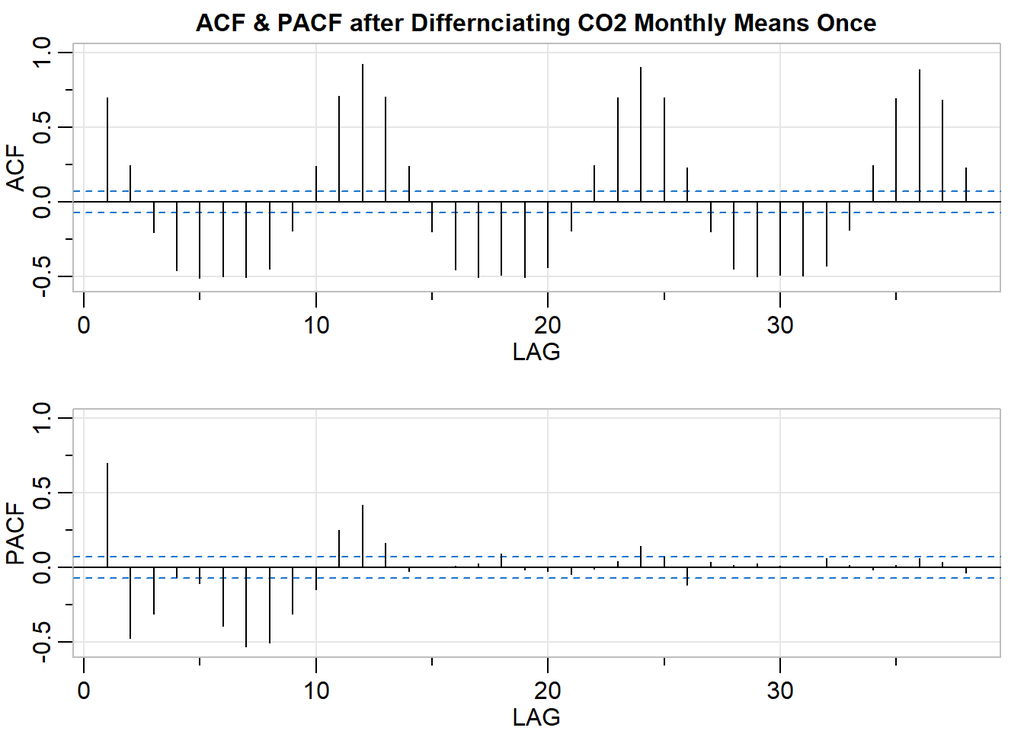

- When I differentiate the data once, the data loses it’s trend and the mean becomes centered at zero. When I fit the SARIMA model to the data, differentiate the data once will likely be enough to make it stationary.
- Seasonality is still visible in the plot. This tells us that both seasonality and trend are sources of variation in the data, and should both be include into our SARIMA model.

#### Fitting Seasonality into the data

```
##
## Call:
## lm(formula = interpolated ~ decimal + factor(`season corr`),
##     data = co2_mm)
##
## Residuals:
##    Min     1Q Median     3Q    Max
## -5.183 -2.954 -1.397  2.185  9.754
##
## Coefficients:
##                           Estimate Std. Error  t value Pr(>|t|)
## (Intercept)             -2.776e+03  1.553e+01 -178.723  < 2e-16 ***
## decimal                  1.574e+00  7.803e-03  201.719  < 2e-16 ***
## factor(`season corr`)2   6.289e-01  6.869e-01    0.916 0.360210
## factor(`season corr`)3   1.494e+00  6.842e-01    2.184 0.029284 *
## factor(`season corr`)4   2.643e+00  6.842e-01    3.863 0.000122 ***
## factor(`season corr`)5   2.931e+00  6.869e-01    4.267 2.24e-05 ***
## factor(`season corr`)6   2.223e+00  6.869e-01    3.236 0.001266 **
## factor(`season corr`)7   5.880e-01  6.869e-01    0.856 0.392286
## factor(`season corr`)8  -1.553e+00  6.869e-01   -2.261 0.024044 *
## factor(`season corr`)9  -3.248e+00  6.869e-01   -4.728 2.72e-06 ***
## factor(`season corr`)10 -3.340e+00  6.869e-01   -4.863 1.42e-06 ***
## factor(`season corr`)11 -2.134e+00  6.869e-01   -3.107 0.001962 **
## factor(`season corr`)12 -9.555e-01  6.869e-01   -1.391 0.164620
## ---
## Signif. codes:  0 '***' 0.001 '**' 0.01 '*' 0.05 '.' 0.1 ' ' 1
##
## Residual standard error: 3.824 on 733 degrees of freedom
## Multiple R-squared:  0.9824, Adjusted R-squared:  0.9821
## F-statistic:  3408 on 12 and 733 DF,  p-value: < 2.2e-16
```

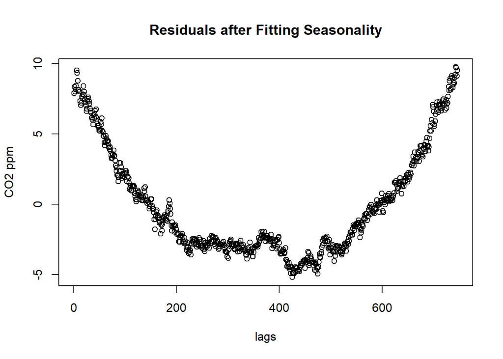

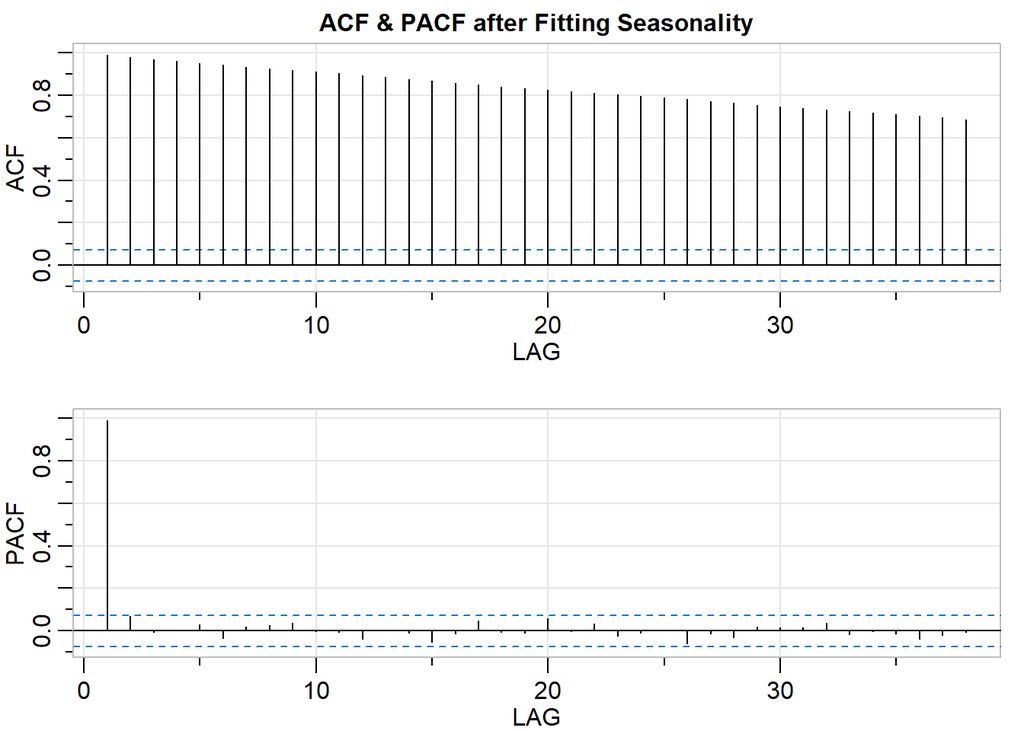

```
## Analysis of Variance Table
##
## Model 1: interpolated ~ decimal
## Model 2: interpolated ~ decimal + factor(`season corr`)
##   Res.Df   RSS Df Sum of Sq      F    Pr(>F)
## 1    744 14019
## 2    733 10721 11    3297.7 20.497 < 2.2e-16 ***
## ---
## Signif. codes:  0 '***' 0.001 '**' 0.01 '*' 0.05 '.' 0.1 ' ' 1
```

- *season corr* is the month in which the CO2 measurement was taken. The variable allows us to explore the role of seasonality plays in CO2 concentration.
- The months are in number format, and I converted them into factors so they would be analyzed as a categorical valiable. They do not really behave in the same way that the numerical scale does. January and December are the farthest in the numerical scale, but probably have more in common than perhaps June and January.
- This model actually has a higher R squared than the one with just the date, coming in at a **0.982**. As you are able to see in the anova results above, the added predictor is actually very significant, and helps to capture a lot more information on the data.
- The residuals still show the quadratic trend, so that will be the next thing I add to the model.
- The ACF no longer has the sinusoidal behavior, but it remains significant for many lags. However, the PACF falls within the significance boundaries within one lag.

#### Fitting a Quadratic term into the Model

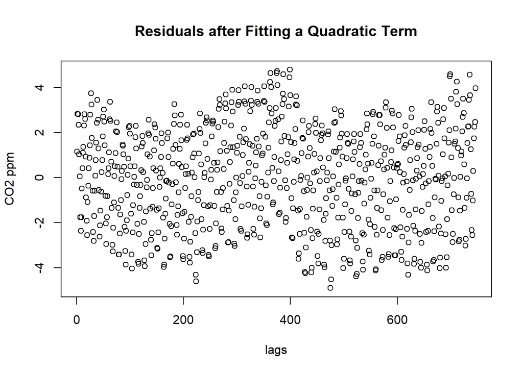

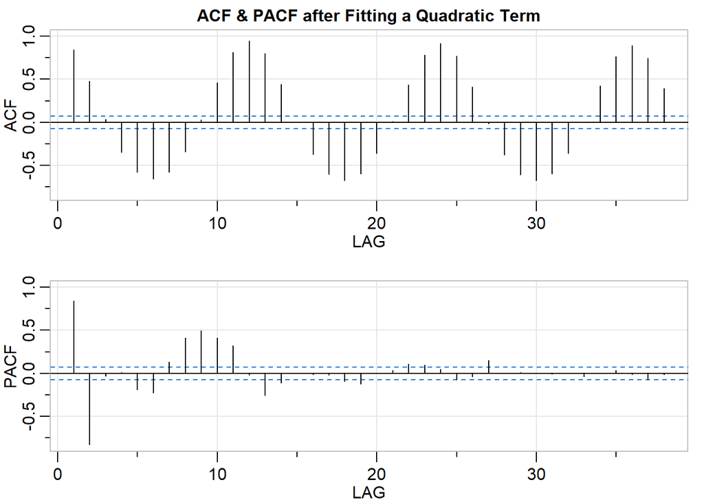

```
## Analysis of Variance Table
##
## Model 1: interpolated ~ decimal + factor(`season corr`)
## Model 2: interpolated ~ decimal + I(decimal^2)
##   Res.Df     RSS  Df Sum of Sq F Pr(>F)
## 1    733 10721.1
## 2    743  3674.5 -10    7046.6
```

- We have finally come around to fitting a quadratic term into the model! I have chosen to add this predictor on its own before adding in seasonality in order to see how it behaves individually. Our R squared has again improved to a **0.994**.
- The residuals are constantly distributed around the zero line and there seems to be no apparent trend.
- As expected, when we remove seasonality from the model, the ACF returned to the sinusoidal behavior, and the PACF seems to lose significance at about 20 lags.

#### Combining Trend, Seasonality, and the Quadratic Term into one Model

```
##
## Call:
## lm(formula = interpolated ~ decimal + I(decimal^2) + factor(`season corr`),
##     data = co2_mm)
##
## Residuals:
##     Min      1Q  Median      3Q     Max
## -1.7401 -0.5702 -0.1565  0.5624  2.1951
##
## Coefficients:
##                           Estimate Std. Error  t value Pr(>|t|)
## (Intercept)              4.820e+04  3.934e+02  122.523  < 2e-16 ***
## decimal                 -4.968e+01  3.956e-01 -125.603  < 2e-16 ***
## I(decimal^2)             1.288e-02  9.943e-05  129.584  < 2e-16 ***
## factor(`season corr`)2   6.282e-01  1.405e-01    4.471 9.00e-06 ***
## factor(`season corr`)3   1.361e+00  1.399e-01    9.727  < 2e-16 ***
## factor(`season corr`)4   2.510e+00  1.399e-01   17.936  < 2e-16 ***
## factor(`season corr`)5   2.931e+00  1.405e-01   20.860  < 2e-16 ***
## factor(`season corr`)6   2.223e+00  1.405e-01   15.823  < 2e-16 ***
## factor(`season corr`)7   5.885e-01  1.405e-01    4.189 3.14e-05 ***
## factor(`season corr`)8  -1.552e+00  1.405e-01  -11.049  < 2e-16 ***
## factor(`season corr`)9  -3.246e+00  1.405e-01  -23.109  < 2e-16 ***
## factor(`season corr`)10 -3.339e+00  1.405e-01  -23.770  < 2e-16 ***
## factor(`season corr`)11 -2.133e+00  1.405e-01  -15.186  < 2e-16 ***
## factor(`season corr`)12 -9.550e-01  1.405e-01   -6.798 2.20e-11 ***
## ---
## Signif. codes:  0 '***' 0.001 '**' 0.01 '*' 0.05 '.' 0.1 ' ' 1
##
## Residual standard error: 0.7822 on 732 degrees of freedom
## Multiple R-squared:  0.9993, Adjusted R-squared:  0.9993
## F-statistic: 7.65e+04 on 13 and 732 DF,  p-value: < 2.2e-16
```

```
## Analysis of Variance Table
##
## Model 1: interpolated ~ decimal + I(decimal^2)
## Model 2: interpolated ~ decimal + I(decimal^2) + factor(`season corr`)
##   Res.Df    RSS Df Sum of Sq      F    Pr(>F)
## 1    743 3674.5
## 2    732  447.8 11    3226.7 479.46 < 2.2e-16 ***
## ---
## Signif. codes:  0 '***' 0.001 '**' 0.01 '*' 0.05 '.' 0.1 ' ' 1
```

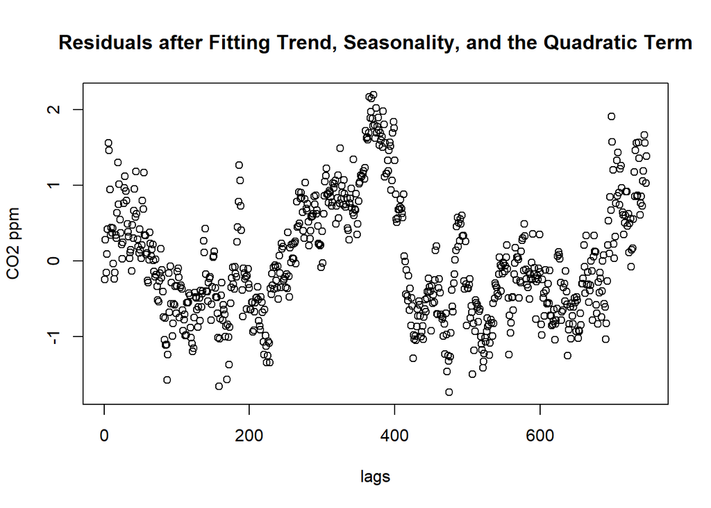

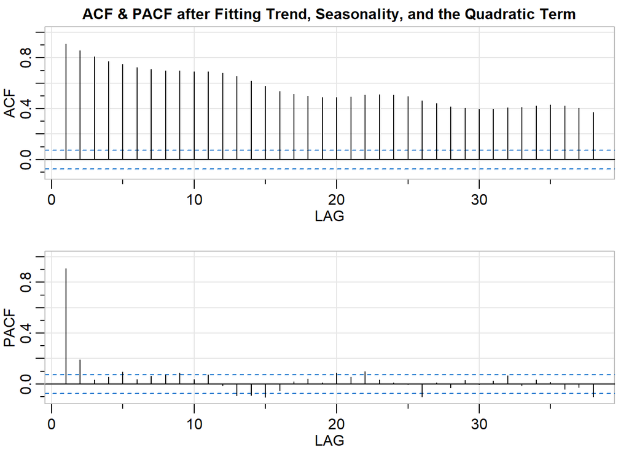

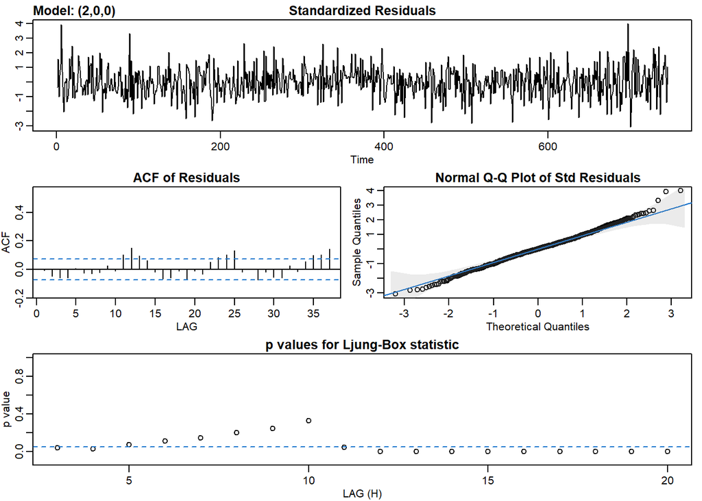